# R tutorial

Assessing the quality of offshore Binomial sampling biosecurity inspections using onshore inspections.

Raphael Trouve, Anthony D. Arthur, and Andrew P. Robinson

April 2021

```r
# Suppress Stan progress bars and messages
  knitr::opts_chunk$set(warning = FALSE, message = FALSE)
# load libraries
  library(ggplot2)                          # Create figures
  library(data.table)                       # Streamline applying a function to each group.
  library(emdbook)                          # Sample from a beta-binomial distribution
  library(rstan)                            # Bayesian inference using Stan
  library(bang)                             # For conjugate beta-binomials models and posterior predictive checks
# Load custom functions (these files should be located in the same folder as the R notebook)
  source('simulate_onshore_inspections.R')  # Simulate an onshore inspection
  source('fit_stan_model.R')                # Function to fit the Stan model and recover the posterior distribution of n1
  source('prop_n1_below_above_threshold.R') # Function to compute the proportion of posterior distribution of n1 that is above a certain threshold value
  source('stan_beta_binomial.R')            # Load Beta-Binomial Stan model in R
  set.seed(1001)                            # Set the random seed of the R session to allow reproducible simulations
```

## Introduction

This R notebook illustrates how to use R and Stan to run the analyses presented in the manuscript entitled: `Assessing the quality of offshore Binomial sampling biosecurity inspections using onshore inspections’ published in Ecological Applications.

To save computation time when running the analyses on a notebook, we have reduced the number of simulations and Stan fit MCMC iterations compared to the analyses presented in the manuscript. We also illustrates our analyses on a single pathway in the notebook (the Orchid pathway) vs. six pathways in the manuscript.

To successfully run this notebook, the `fit_stan_model.R',`prop_n1_below_above_threshold.R’, `simulate_onshore_inspections.R', and`stan_beta_binomial.R’ files should be located in the same folder as the notebook. The `ggplot2',`data.table’, `emdbook',`rstan’, and `bang’ packages will also need to be installed in the computer.

## Calibrating the reference distribution from past inspection data on the pathway

The first step of the analysis is to calibrate the reference distribution, i.e., the distribution of infestation rate typically found among consignments of the pathway, from past inspection data. The R code below illustrates how to use the `bang’ package to fit this reference distribution.

```r
# Fit a beta binomial distribution to past inspection data on the pathway (figure 3 of the manuscript)
  # Simulate past data based on the Orchid pathway in the manuscript (a = 0.193, b = 8.82).
  # For confidentiality reasons, we will used simulated data rather than the original dataset in this tutorial.
    k = simulate_onshore_inspections(n_cons = 320, a = 0.193, b = 8.82, n2 = 600) # Vector of k infested units found in n_cons past onshore inspections
  # Fit Beta-Binomial model to past data on the pathway
    data_for_hef <- cbind.data.frame(y = k, n = rep(600, 320))
    reference_distribution <- hef(model = "beta_binom", data = data_for_hef, nrep = 50, n = 2000)
  # Posterior mean of the parameters and posterior predictive check of the model
    parameter_values <- cbind.data.frame(reference_distribution$sim_vals)
    colMeans(parameter_values)
```

```
##     alpha      beta
## 0.2119233 8.0162804
```

```r
    pp_check(reference_distribution, 'ecdf_overlay', discrete = T)
```

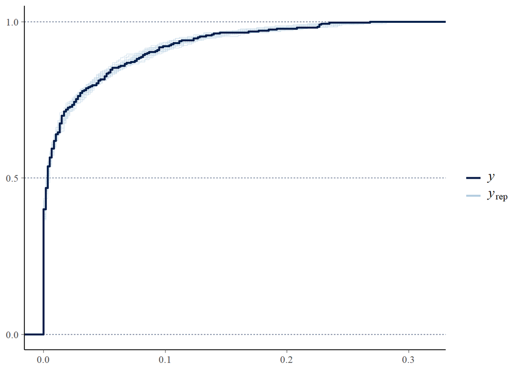

## Posterior distribution of n1 for different number of infested sample found in a single onshore inspection

After collecting onshore inspection data, we can make inference on the offshore inspection sample size n1. Inference on n1, in the form of a posterior distribution, will depend on the number of infested units k found onshore.

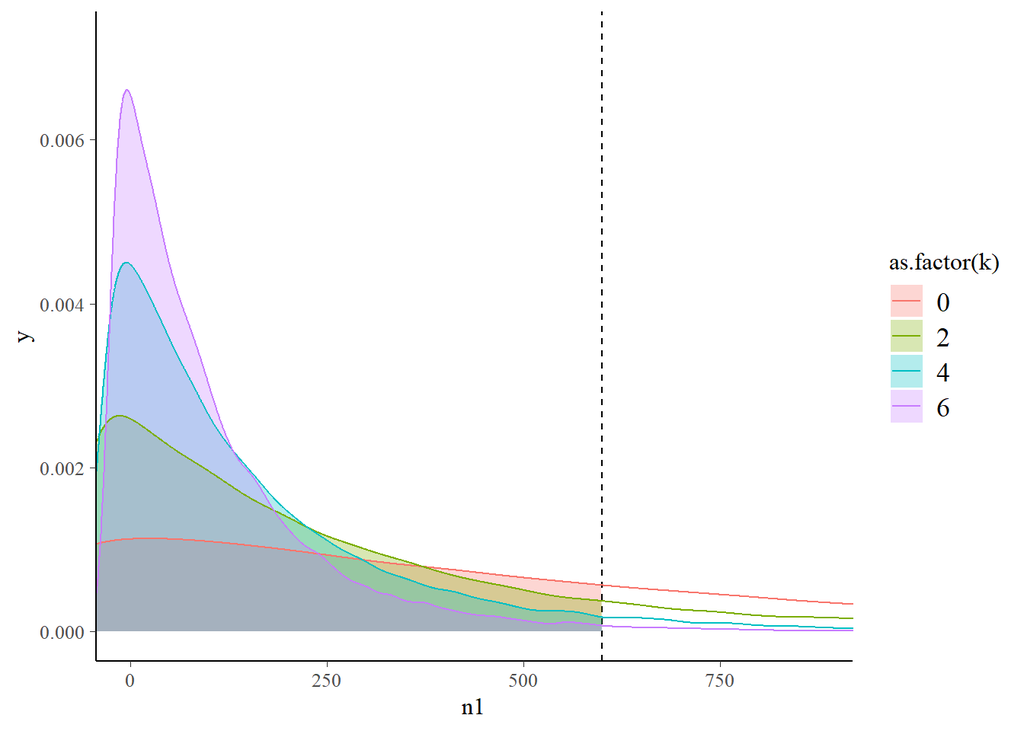

```r
# Bayesian inference on n1 when varying the number of infested sample found k found in a single onshore inspection (figure 2)
  # Compile Stan model
    stan_beta_binomial_compiled <- stan_model(model_code = stan_beta_binomial)
  # Experimental design
    data_sim <- expand.grid(k = c(0, 2, 4, 6), n2 = 600, a = 0.193, b = 8.82, prior_expected_n1 = 600) # Vary k, use parameters values from the Orchid pathway
    data_sim <- as.data.table(data_sim)
  # Fit a separate Stan model for each value of k.
    data_results <- data_sim[, fit_stan_model(model = stan_beta_binomial_compiled,
                                              n2 = n2,
                                              a = a,
                                              b = b,
                                              k = k,
                                              prior_expected_n1 = prior_expected_n1,
                                              warmup = 6000,
                                              iter = 11000,
                                              chain = 10),
                             by = k]
  # Generate density kernel for the figure
    density_kernel <- data_results[, list(x = density(x = n1, n = 10000, adjust = 1.9)$x,
                                          y = density(x = n1, n = 10000)$y,
                                          adjust = 1.9),
                                   by = k]
  # Plot
    ggplot(data = data_results, aes(n1, col = as.factor(k))) +
      coord_cartesian(xlim = c(0, 875), ylim = c(0, 0.0072)) +
      geom_vline(xintercept = 600, lty = 2) +
      geom_ribbon(data = density_kernel[x <= 600, ], aes(x = x, ymax = y, fill = as.factor(k)), ymin = 0, col = NA, alpha = 0.3) +
      geom_line(data = density_kernel, aes(x, y, col = as.factor(k)))
```

```r
  # Proportion of posterior n1 probability below threshold
    data_results[, .(prop_n1_below_600 = round(sum(n1 < 600) / .N, 2)), by = k]
```

```
##    k prop_n1_below_600
## 1: 0              0.58
## 2: 2              0.85
## 3: 4              0.95
## 4: 6              0.99
```

## How many infested samples onshore in a single inspection are sufficient to reject the presence of an offshore inspection?

Rather than show the whole posterior distribution of n1, we might only be interested in the proportion of the posterior probability distribution of n1 that falls below a prescribed n1 value. The R code below shows how to compute this quantity from a Stan fit and how it varies with the number of infested units k found in a single onshore inspection.

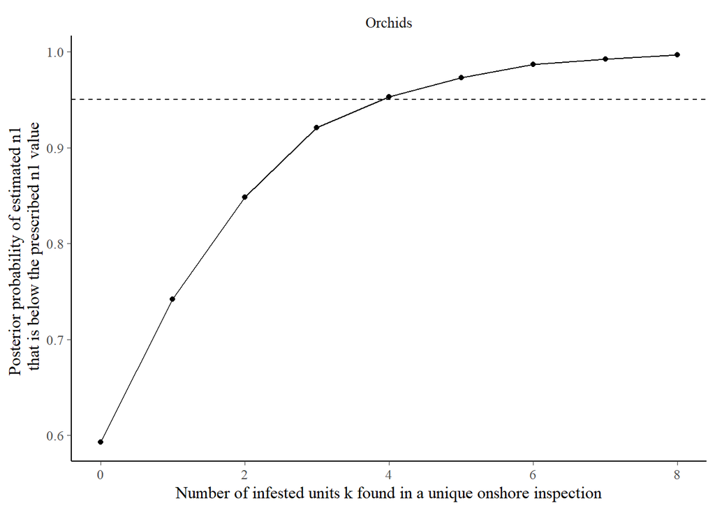

```r
# Posterior probability of estimated n1 that is below the prescribed n1 value vs. k (figure 4)
  # Design of the computational experiment for the Orchids pathway.
    data_sim <- data.table(pathway = 'Orchids',
                           k = seq(0, 8, by = 1),
                           n2 = 600,
                           prior_expected_n1 = 600,
                           a = 0.193,
                           b = 8.82)
  # Fit the Stan beta-binomial model per pathway and per k value
    data_results <- data_sim[, prop_n1_below_above_threshold(n1 = as.data.frame(fit_stan_model(model = stan_beta_binomial_compiled,
                                                                                               n2 = n2,
                                                                                               a = a,
                                                                                               b = b,
                                                                                               k = as.array(k),
                                                                                               prior_expected_n1 = prior_expected_n1,
                                                                                               iter = 11000,
                                                                                               chains = 1),  # chain = 10 in the manuscript
                                                                                               pars = 'n1')$n1, # Posterior distribution of n1 obtained from a Stan fit
                                                             below_threshold = prior_expected_n1,
                                                             above_threshold = 400),
                             by = .(pathway, k)] # Compute for each pathway and each k
  # Plot
    ggplot(data = data_results, aes(k, prop_below)) +
      geom_point() +
      geom_line() +
      facet_wrap(~pathway) +
      geom_hline(yintercept = 0.95, lty = 2) +
      xlab('Number of infested units k found in a unique onshore inspection') +
      ylab('Posterior probability of estimated n1 \n that is below the prescribed n1 value')
```

## How many successive inspections are necessary to reject or accept the presence of an offshore inspection in practice?

While it is useful to know how our ability to reject the presence of an offshore inspection changes with the number of infested units k found in a single onshore inspection, to get a more complete picture of how the method will work in practice we also need to know how frequently we expect to see each k values for different pathways. Additionally, it is also useful to know how the method will perform when combining data from several onshore inspections.

The below R code runs a statistical power analysis computing how many inspected onshore consignments would be necessary in practice before making a decision on the presence or absence of appropriate offshore inspection.

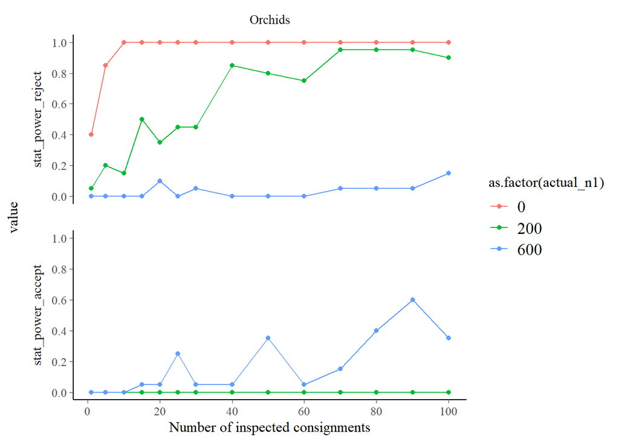

```r
# Statistical power to reject and accept the presence of a quality offshore inspection vs. number of onshore inspections (figures 5 and 6)
  # Design of the computational experiment for the Orchids pathway.
  # Note that we only ran 20 simulation in the notebook (vs. 10,000 in the manuscript) to save time.
  # We also reduced the number of iterations of the Stan fit compared to the manuscript
    data_sim <- expand.grid(pathway = 'Orchids', n_cons = c(1, seq(5, 25, by = 5), seq(30, 100, by = 10)), sim = 1:20, actual_n1 = c(0, 200, 600))
    data_sim <- as.data.table(data_sim)
    data_sim[, n2 := 600]
    data_sim[, prior_expected_n1 := 600]
    data_sim[, a := 0.193]
    data_sim[, b := 8.82]
  # Fit a Stan beta-binomial model for each combination of pathway, number of onshore inspections, actual_n1, and simulations (i.e., replicates).
    data_results <- data_sim[, prop_n1_below_above_threshold(n1 = as.data.frame(fit_stan_model(model = stan_beta_binomial_compiled,
                                                                                               n2 = n2,
                                                                                               a = a,
                                                                                               b = b,
                                                                                               k = as.array(simulate_onshore_inspections(n_cons = n_cons, a = a, b = b + actual_n1, n2 = n2)), # Simulate k
                                                                                               prior_expected_n1 = prior_expected_n1,
                                                                                               iter = 2000, # iter = 11000 in the manuscript
                                                                                               chain = 1),
                                                                                               pars = 'n1')$n1,
                                                             below_threshold = 600,
                                                             above_threshold = 400),
                             by = .(pathway, n_cons, sim, actual_n1)]
  # Compute statistical power
    data_results_summary <- data_results[, .(stat_power_reject = sum(prop_below > 0.95) / .N,
                                             stat_power_accept = sum(prop_above > 0.95) / .N),
                                         by = .(pathway, n_cons, actual_n1)]
    data_results_summary_long <- melt(data_results_summary, id.vars = c('pathway', 'n_cons', 'actual_n1'))
  # Plot
    ggplot(data = data_results_summary_long, aes(n_cons, value, col = as.factor(actual_n1))) +
      geom_point() +
      geom_line() +
      facet_grid(variable ~ pathway, switch = 'y') +
      scale_x_continuous(breaks = seq(0, 100, by = 20)) +
      scale_y_continuous(breaks = seq(0, 1, by = 0.2), limits = c(0, 1)) +
      xlab('Number of inspected consignments')
```